# Assignment 6

## Try to submit as an HTML file

Print your Emory code below

```python
print("2644681")
```

[output not shown]

Import the "pandas" and "matplotlib.pyplot" libraries

```python
# Write your answer here:

import pandas as pd
import matplotlib.pyplot as plt
```

(a) Functions

- Read the dataset labelled features.csv.
- Create a `lambda` function that checks if displacement $>$ 200
- Create a new list that shows true if displacement $>$ 200 and false

if displacement $\leq$ 200.

- Count how many cars have displacement $> 200$.

To get full credit use either the apply or the map function  
(see Lectures 7 and 8)

```python
# Write your answer here:

df = pd.read_csv("data/features.csv")

check_displacement = lambda d: d > 200

df["displacement_above_200"] = df["displacement"].apply(check_displacement)

num_cars_above_200 = df["displacement_above_200"].sum()

print("Number of cars with displacement > 200:", num_cars_above_200)
```

```
Number of cars with displacement > 200: 158
```

[output not shown]

(b) Subsetting Data

- Read the dataset labelled features.csv.
- Define a global variable called `threshold` that takes the

value 2588

- Subset the data to get one dataset with weight $>$ threshold and

another with weight $\le$ 2588. Use the `.query()` function.

- Compute the mean acceleration for each of these datasets.

Note: Review how to define a gloabl variable inside `.query()`

```python
df = pd.read_csv("data/features.csv")
threshold = 2588

df_above = df.query("weight > @threshold")   # Cars with weight > 2588
df_below_equal = df.query("weight <= @threshold")  # Cars with weight ≤ 2588

mean_acc_above = df_above["acceleration"].mean()
mean_acc_below_equal = df_below_equal["acceleration"].mean()

print("Mean acceleration for cars with weight > 2588:", mean_acc_above)
print("Mean acceleration for cars with weight ≤ 2588:", mean_acc_below_equal)
```

```
Mean acceleration for cars with weight > 2588: 14.972457627118644
Mean acceleration for cars with weight ≤ 2588: 16.435802469135798
```

(c) Use sorting + ".iloc[]"

- Read the "fifa23_players_basic.csv" dataset
- Use ".sort_values()" to order the "Age" column

from youngest to oldest

- Get a subset with the 5 youngest players

```python
# Write your answer here:

df = pd.read_csv("data/fifa23_players_basic.csv")

df_sorted = df.sort_values(by="Age", ascending=True)

youngest_players = df_sorted.iloc[:5, :]

print(youngest_players[["Full Name", "Age"]])
```

```
             Full Name  Age
17956  Andreas Dithmer   16
18014      José Ardila   16
16084      Serge Ngoma   16
11481      Obed Vargas   16
17591  Alan Madaliński   16
```

(d) Use queries + global variables

- Read the "fifa23_players_basic.csv" dataset
- Compute the mean of the column "Wage(in Euro)"

and store it as a variable

- Subset the players whose value is above the mean value  
  using ".query()"

HINT: Remember that there is a special syntax for  
when the column names have spaces (see Lecture 10)  
Reference the column as `` `Wage(in Euro)` `` inside .query()

```python
df = pd.read_csv("data/fifa23_players_basic.csv")

mean_wage = df["Wage(in Euro)"].mean()

high_wage_players = df.query("`Wage(in Euro)` > @mean_wage")

print(high_wage_players[["Full Name", "Wage(in Euro)"]])
```

```
                      Full Name  Wage(in Euro)
0                  Lionel Messi         195000
1                 Karim Benzema         450000
2            Robert Lewandowski         420000
3               Kevin De Bruyne         350000
4                 Kylian Mbappé         230000
...                         ...            ...
14279                Adam Lewis          11000
15117                Ben Knight          12000
15441  Thanawat Suengchitthawon           9000
15957              Paul Glatzel          11000
16157         Caleb Chukwuemeka           9000

[4300 rows x 2 columns]
```

(e) Plot by Category

Read the "data/wdi_urban.csv" dataset.

This contains data from 1980 and 2020.

- **Create a list with the unique values of "year"**
- **Create a plot with a ...**
  - Histogram of "prop_urbanpopulation" for each year
  - Set the histogram option `alpha = 0.5` for transparency
  - All the histograms should be overlapping
  - Create a legend with the list of years
  - Label the axes and the title

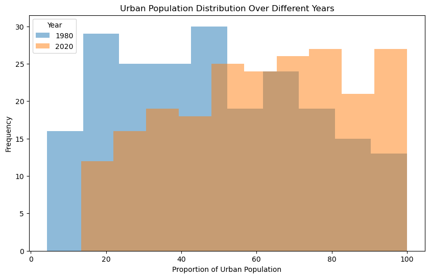

```python
df = pd.read_csv("data/wdi_urban.csv")

unique_years = df["year"].unique()

plt.figure(figsize=(10, 6))

for year in unique_years:
    subset = df[df["year"] == year]
    plt.hist(subset["prop_urbanpopulation"], alpha=0.5, label=str(year))

plt.xlabel("Proportion of Urban Population")
plt.ylabel("Frequency")
plt.title("Urban Population Distribution Over Different Years")
plt.legend(title="Year")
plt.show()
```